# Comparing page load times

Dominik Strohmeier, Mozilla

11/11/2017

## Intro

This notebook analysis data that was collected by [Disconnect](https://disconnect.me/) and [Mozilla](https://www.mozilla.org/en-US/) to compare page load speed of different browsers.

Browsers under test:

- Google Chrome v62
- Google Chrome in Incognito mode
- Firefox Quantum (v57)
- Firefox Quantum (v57) in Private Browsing mode with Tracking Protection

```r
library(dplyr, warn.conflicts = FALSE)
library(ggplot2, warn.conflicts = FALSE)
library(tidyr, warn.conflicts = FALSE)
library(scales, warn.conflicts = FALSE)
library(data.table, warn.conflicts = FALSE)

# colorblind-friendly colors
cbPalette <- c("#999999", "#E69F00", "#56B4E9", "#009E73", "#F0E442", "#0072B2", "#D55E00", "#CC79A7")

# read data from results csv file. Reading timestamps as character to keep it readible.
tp_data <- fread("pageloadstudy.csv", colClasses = list(character=3:25))

# replace strings for different Browsers
tp_data <- tp_data[Browser == "chrome_normal", Browser := "Chrome"]
tp_data <- tp_data[Browser == "chrome_private", Browser := "Chrome Incognito"]
tp_data <- tp_data[Browser == "firefox_normal", Browser := "Firefox Quantum"]
tp_data <- tp_data[Browser == "firefox_private", Browser := "Firefox Quantum Private Browsing"]
```

In our study, we collected [performance.timing](https://developer.mozilla.org/en-US/docs/Web/API/PerformanceTiming) data for 200 news websites that were loaded 10 times each in every browser. Here is a sample of the data as example:

```r
# create difference between two timestamps
# we are interested in the difference between each of the timestamps and navigationStart
perf_timings <- tp_data %>%
  mutate_at(.vars = vars(-Domain, -Browser, -`Load Time`), .funs = funs(diff = as.numeric(.)-as.numeric(navigationStart))) %>%
  select(Domain, Browser, ends_with("diff")) %>%
  mutate_if(is.numeric, funs(replace(., .<0, NA))) %>%
  select_if(~sum(!is.na(.)) > 0)

names(perf_timings) <- gsub("_diff", "", names(perf_timings))

#display sample of data_perf in notebook
sample_n(perf_timings, 3)
```

```
##                         Domain                          Browser
## 1288        http://Reuters.com Firefox Quantum Private Browsing
## 3920 http://Washingtonpost.com Firefox Quantum Private Browsing
## 3156    http://Thestranger.com Firefox Quantum Private Browsing
##      navigationStart fetchStart domainLookupStart domainLookupEnd
## 1288               0        195               195             195
## 3920               0         85                85              85
## 3156               0        132               132             132
##      connectStart connectEnd secureConnectionStart requestStart
## 1288          195        195                     0          224
## 3920           85        205                     0          205
## 3156          132        132                     0          171
##      responseStart responseEnd domLoading domInteractive
## 1288           244         246        252           1067
## 3920           306         314        312            889
## 3156           201         239        203           3135
##      domContentLoadedEventStart domContentLoadedEventEnd domComplete
## 1288                       1098                     1111        2061
## 3920                       1006                     1008        1591
## 3156                       3136                     3144        9857
##      loadEventStart loadEventEnd timeToNonBlankPaint unloadEventStart
## 1288           2061         2073                 571               NA
## 3920           1592         1842                 627               NA
## 3156           9857         9859                3065               NA
##      unloadEventEnd redirectStart redirectEnd
## 1288             NA            NA          NA
## 3920             NA            NA          NA
## 3156             NA            NA          NA
```

## Comparing means per browser

To analyze the data, let’s look for at the mean page load time for each browser and compare differences.

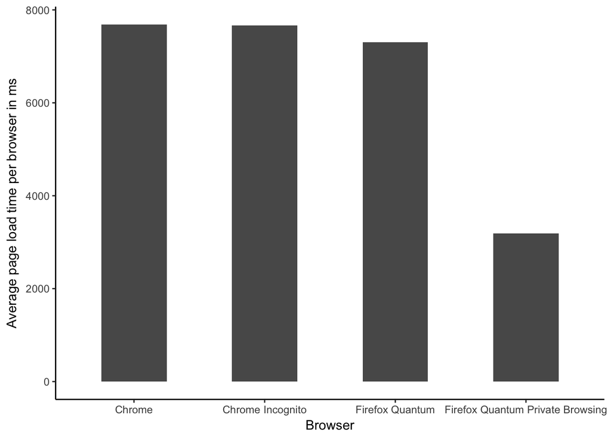

```r
by_browser <- perf_timings %>%
  group_by(Browser) %>%
  summarize(means = mean(loadEventEnd))

ggplot(by_browser, aes(Browser, means)) +
  geom_bar(stat = "identity", width = 0.5) +
  scale_fill_manual(values=cbPalette) +
  theme_classic() +
  labs(y = "Average page load time per browser in ms")
```

The difference between Chrome’s Incognito mode and Firefox Quantum Private Browsing is **2.4x**. It is also visible that there is no difference between Chrome’s normal and Incognito mode. This shows that the differences between Firefox Quantum and its Private Browser option, which is similar to Chrome’s Incognito mode + Tracking Protection, come from Tracking Protection.

## Analyzing stability of results through bootstrapping

The previously calculated mean is the result of averaging across all 2000 measurement per browser. However, sessions are usually shorter. One way to analyze the stability of the results is through bootstrapping. We select a random set of measurements per browser, calculate means per browser and store these. Then, we repeat this, let’s say, 10,000 times, and plot distribution of differences between Chrome Incognito and Firefox Quantum Tracking Protection afterwards.

```r
# create empty variables to hold our bootstrapping data
bootstrap <- data.frame(Browser = character(), means = integer())
distance <- c()

# perform 500 repetitions of sample calculations
# this is better be done using boot(), looking forward to receive patches
for (x in 1:10000) {
  by_browser <- perf_timings %>%
    group_by(Browser) %>%
    sample_n(200) %>%
    summarize(means = mean(loadEventEnd))

  bootstrap <- bind_rows(bootstrap, by_browser)

  distance[x] <- by_browser$means[by_browser$Browser == "Chrome Incognito"] / by_browser$means[by_browser$Browser == "Firefox Quantum Private Browsing"]
}
```

We can then look at the results of the bootstrapping per browser.

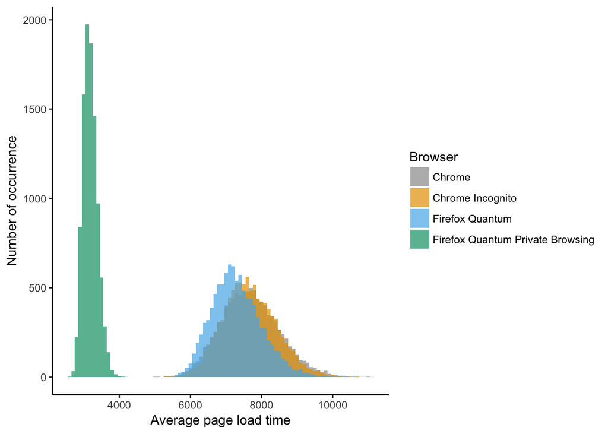

```r
ggplot(bootstrap, aes(means, fill=Browser)) +
  geom_histogram(position="identity", alpha = 0.7, binwidth = 100) +
  scale_fill_manual(values=cbPalette) +
  theme_classic() +
  labs(y = "Number of occurrence", x = "Average page load time", fill = "Browser")
```

More interestingly, we can also plot the distributions of the difference between Chrome and Firefox Quantum.

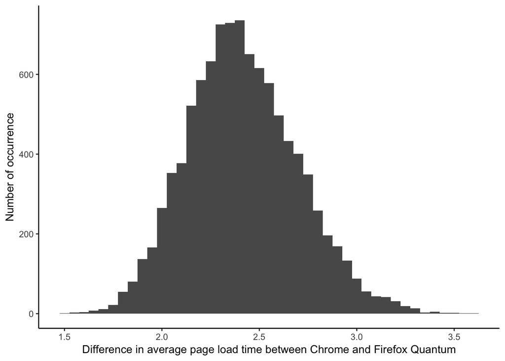

```r
qplot(distance, geom = "histogram", binwidth = 0.05) +
  theme_classic() +
  labs(y = "Number of occurrence", x = "Difference in average page load time between Chrome and Firefox Quantum")
```

To proof stability of our measurements, we can calculate the mean of this difference distribution again which gives us **2.4x** as mean difference of differences between Chrome Incognito and Firefox Quantum Private Browsing.

## Putting simulated measurements into context

One important final step when doing automated performance measurements is to find related results that can be used to put your measurements into context.

SOASTA published results about predicting user bounce rate based on performance timings that they measured in the wild. Average session load time was one of the best performing predictors in [their study](https://www.slideshare.net/tammyeverts/using-machine-learning-to-determine-drivers-of-bounce-and-conversion-66319405).

Their results show that an average session load time of 6 seconds already leads to a 70% bounce rate. Let’s look at the share of pages in our data that has a load time longer than 6 seconds and compare across browsers.

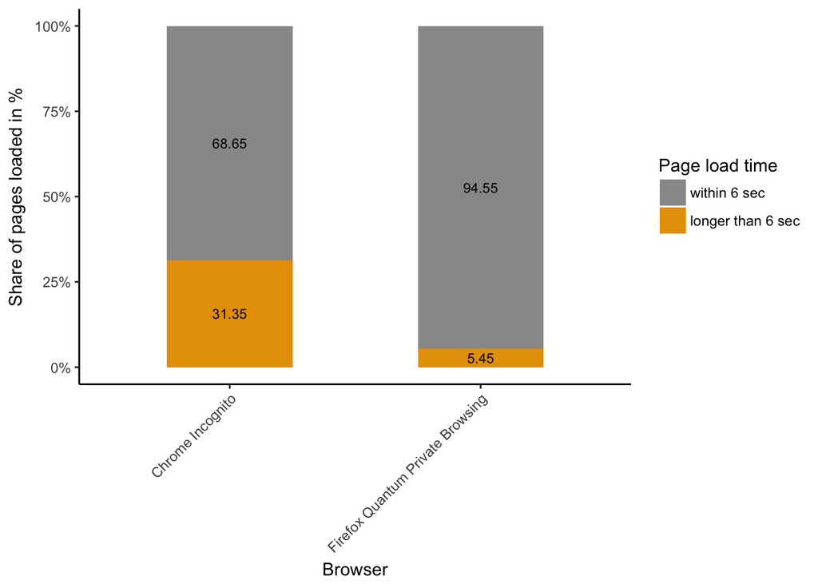

```r
long_loading <- perf_timings %>%
  filter(grepl("Incog|Private", Browser)) %>%
  mutate(islonger = ifelse(loadEventEnd > 6000, 1, 0)) %>%
  group_by(Browser) %>%
  summarize(slow = sum(islonger), fast = n() - slow) %>%
  gather(page_load_time, n, slow:fast) %>%
  mutate(perc = (n / 2000)*100)

long_loading$page_load_time <- factor(long_loading$page_load_time, levels=c("fast", "slow"), labels=c("within 6 sec", "longer than 6 sec"))

ggplot(long_loading, aes(x = Browser, y = perc, fill = page_load_time, label = perc)) +
  geom_bar(stat = "identity", position = "fill", width = 0.5) +
  scale_y_continuous(labels=percent) +
  theme_classic() +
  theme(axis.text.x = element_text(angle = 45, hjust = 1)) +
  labs(y = "Share of pages loaded in %", color = "Page load time", fill = "Page load time") +
  scale_fill_manual(values=cbPalette) +
  geom_text(size = 3, position = position_fill(vjust = 0.5))
```

While only about 5.5% of page loads take longer than 6 seconds for Firefox Quantum, it’s about 31% of all pages for Google Chrome.

## Looking at where the time differences occur

A last, interesting aspect to look into the data is to look at the performance timing timeline and check where the differences between browsers occur. Let’s only look at Chrome Incognito and Firefox Quantum Private Browsing again.

*performance.timing* gives you events along the page load process. Let’s print these events in order of appearance during page load and look at differences between browsers, looking at [newsweek.com](http://Newsweek.com) and [nbcnews.com](http://Nbcnews.com) as an example:

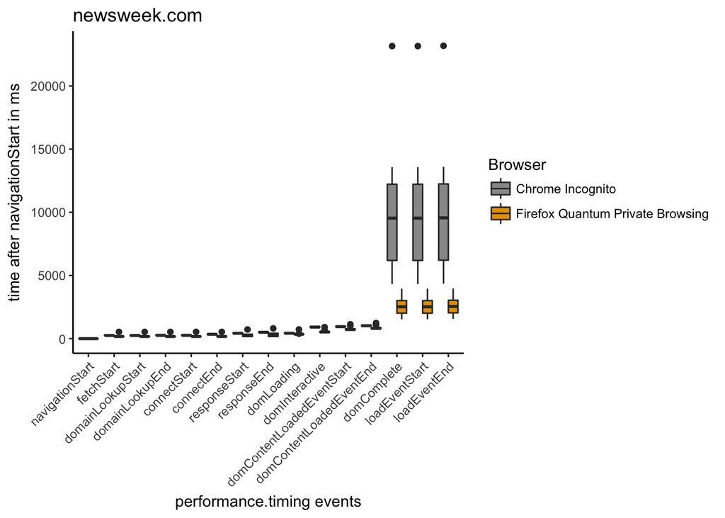

```r
# order of appearance of events during page load
standard = c("navigationStart", "redirectStart", "fetchStart", "domainLookupStart", "domainLookupEnd", "connectStart", "connectEnd", "responseStart", "responseEnd", "domLoading", "domInteractive", "domContentLoadedEventStart", "domContentLoadedEventEnd", "domComplete", "loadEventStart", "loadEventEnd")

perf_timings %>%
  select(-secureConnectionStart, -redirectStart, -redirectEnd, -unloadEventEnd, -unloadEventStart) %>%
  filter(Domain == "http://Newsweek.com" & grepl("Incog|Private", Browser)) %>%
  gather(metric, time, -Domain, -Browser) %>%
  mutate(metric = factor(metric, levels = standard)) %>%
  na.omit() %>%
  ggplot(aes(metric, time, fill = Browser)) + geom_boxplot() +
  scale_fill_manual(values=cbPalette) +
  theme_classic() +
  theme(axis.text.x = element_text(angle = 45, hjust = 1)) +
  labs(y = "time after navigationStart in ms", x = "performance.timing events", title = "newsweek.com")
```

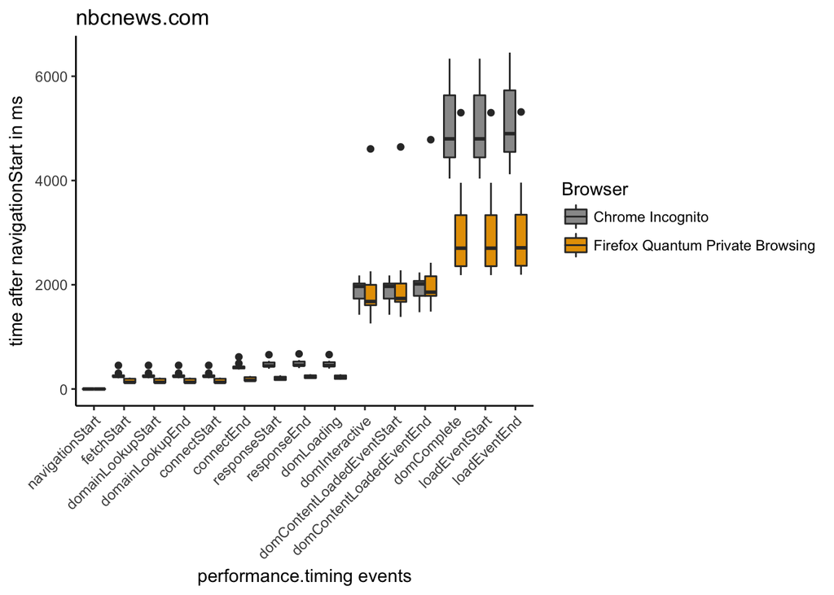

```r
perf_timings %>%
  select(-secureConnectionStart, -redirectStart, -redirectEnd, -unloadEventEnd, -unloadEventStart) %>%
  filter(Domain == "http://Nbcnews.com" & grepl("Incog|Private", Browser)) %>%
  gather(metric, time, -Domain, -Browser) %>%
  mutate(metric = factor(metric, levels = standard)) %>%
  na.omit() %>%
  ggplot(aes(metric, time, fill = Browser)) + geom_boxplot() +
  scale_fill_manual(values=cbPalette) +
  theme_classic() +
  theme(axis.text.x = element_text(angle = 45, hjust = 1)) +
  labs(y = "time after navigationStart in ms", x = "performance.timing events", title = "nbcnews.com")
```

It becomes visible that the main differences occur towards the end of loading process. Work to create the DOM is doing similarly fast in both browsers, but Chrome is waiting for content significantly longer than Firefox as main differences start to occur with domComplete, i.e. the moment in time when the parser finished its work on the main document. This underlines again that Firefox’s Tracking Protection used in Private Browsing blocks slow, very likely third party content from being loaded.